# MA206 Code Movies

A companion for the MA206 Tidyverse Tutorial

#### “MA 206 Code Movies” is a companion guide to the MA206 tidyverse tutorial. It dissects the Tutorial’s code pipelines and presents them *step-by-step*.

#### For discussion of the example data and functions, refer back to the MA206 Tidyverse Tutorial guide.

## 1. Using *Tidyverse* to Explore the Data

### In this example:

#### `read_csv()` read in *comma separated values* file

#### `select()` choose columns

#### `filter()` keep or drop rows

#### `mutate()` create new variable (column)

#### `summarise()` summarize data (sometimes used with `group_by()`)

#### First, we use the *read_csv()* command to bring our data into RStudio, then we look at what the *filter()*, *mutate()*, and *select()* commands can do in a pipeline:

View code-movie in a new tab or below:

[interactive chart not shown]

#### We can also use the *summarize()* command to create new variables for later use. Here, we use it to identify the mean earnings of our sample population:

View code-movie in a new tab or below:

[interactive chart not shown]

## 2. Using *ggplot2* to Explore the Data

### In this example:

#### `ggplot()`, `aes()`, `labs()`, `group_by()`, `facet_wrap()`, `geom_histogram()`, `geom_point()`, `geom_smooth()`, `geom_line()`, `geom_boxplot()`

##### Ex. 2.1: Histogram

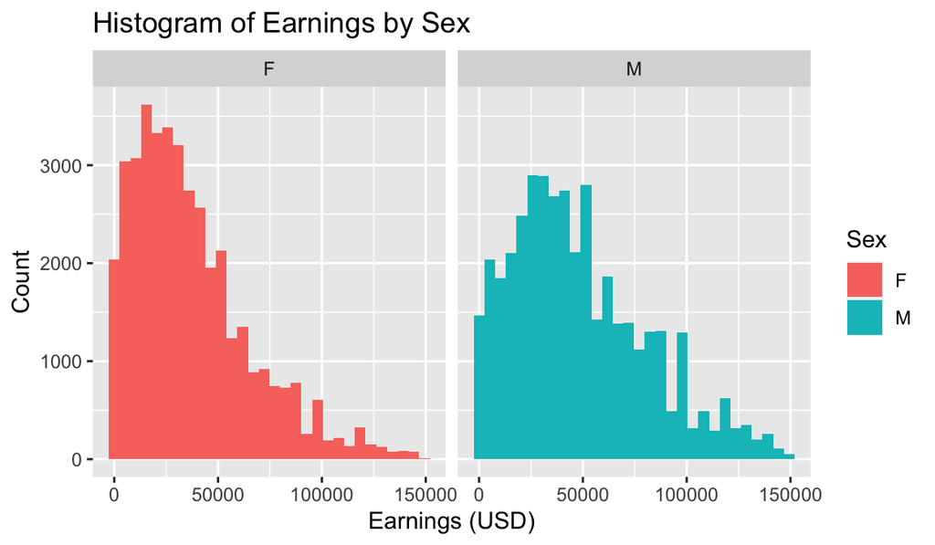

View code-movie in a new tab or below:

[interactive chart not shown]

##### Ex. 2.2: Scatterplot

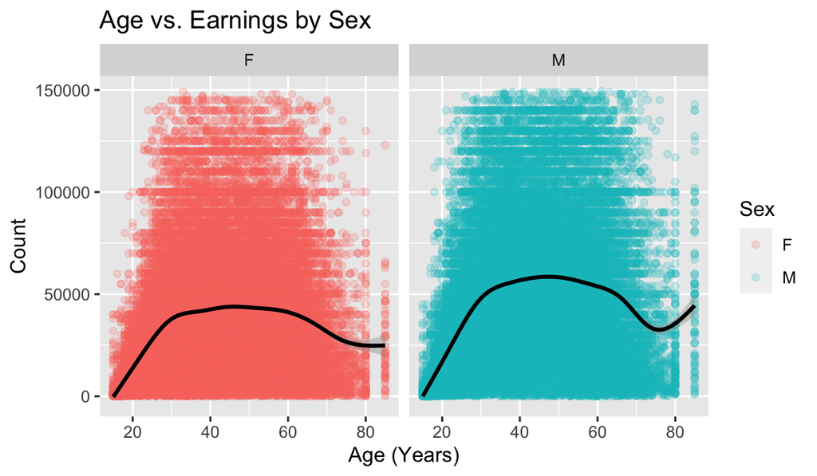

[interactive chart not shown]

View code-movie in a new tab or below:

##### Ex. 2.3: Line Plot

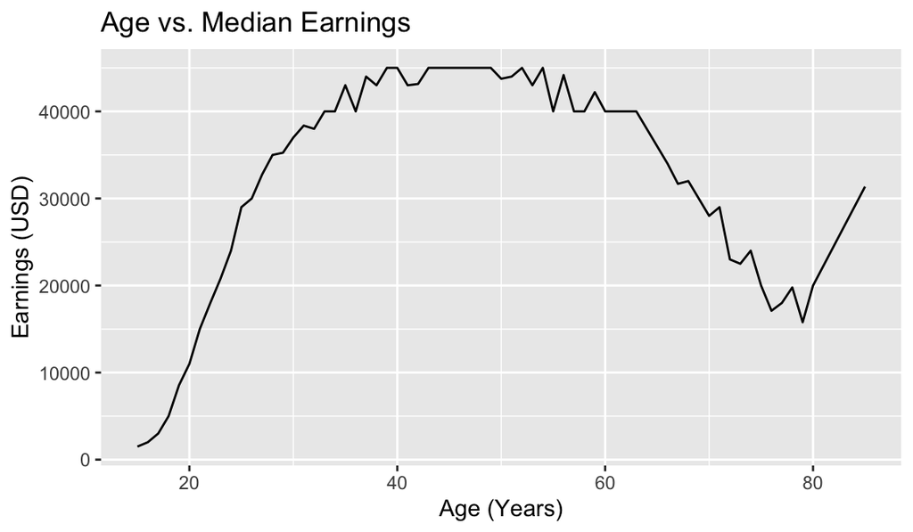

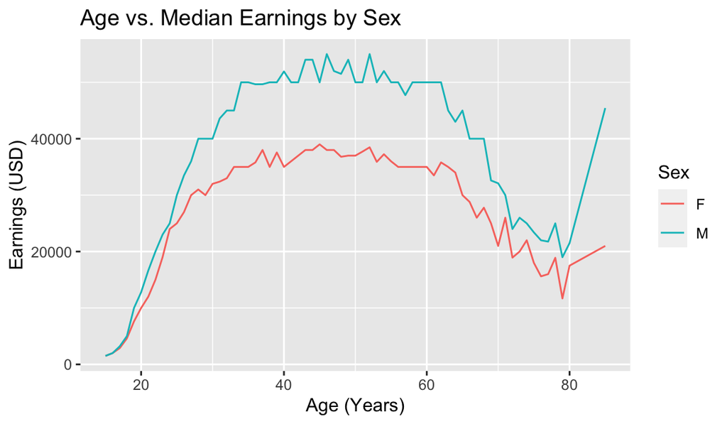

View code-movie in a new tab or below:

[interactive chart not shown]

## 3. Using *ggplot2* functions for data visualization

### In this example:

#### `labs()`, `scale_\*_\*()`, `theme_X()`

##### Labels and scales

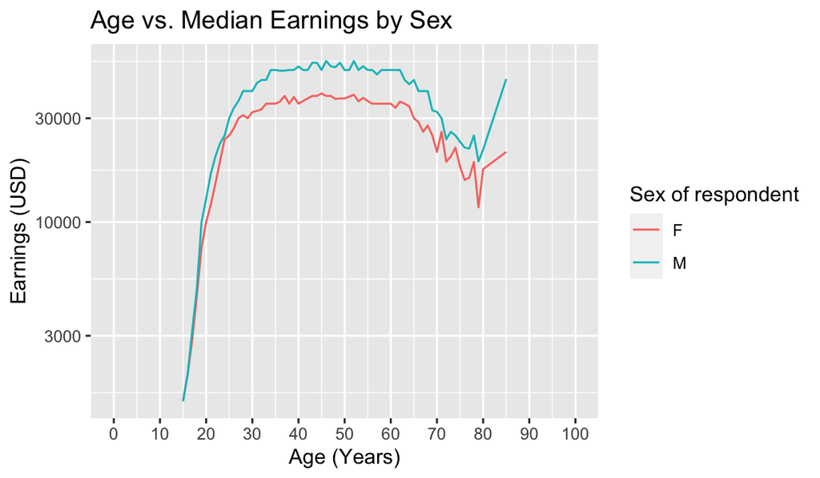

View code-movie in a new tab or below:

[interactive chart not shown]

##### Themes

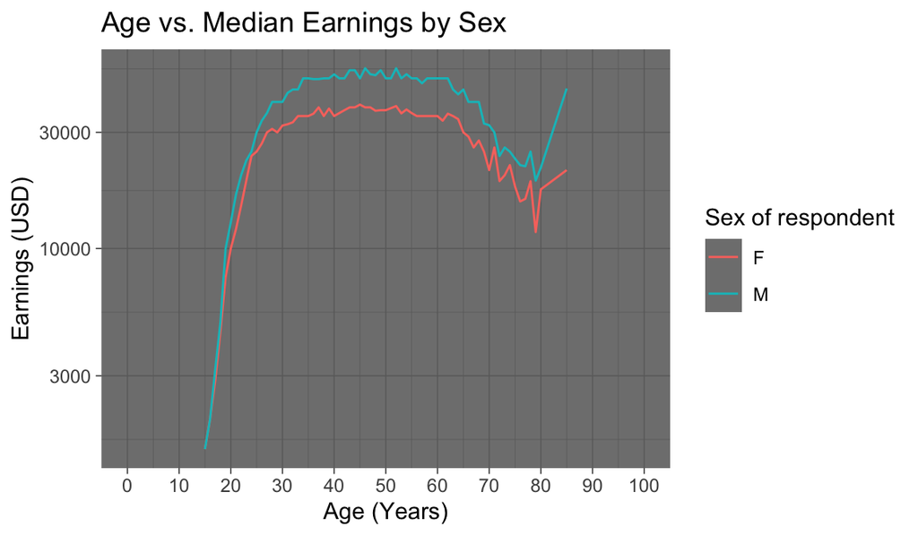

View code-movie in a new tab or below:

[interactive chart not shown]

## 4. Additional *ggplot2* Geometric Objects

### In this example:

#### `geom_col()`, `geom_bar()`, `geom_dotplot()`, `group_by()`, `factor()`, `c()`

#### These demos are not included in the Tidyverse Tutorial, but build on the extra ggplot2 uses mentioned at the end of the section. Additionally, the *Dot Plot* example utilizes 8gapminder* data different from that used in all previous examples.

##### Ex. 4.1: Column Chart

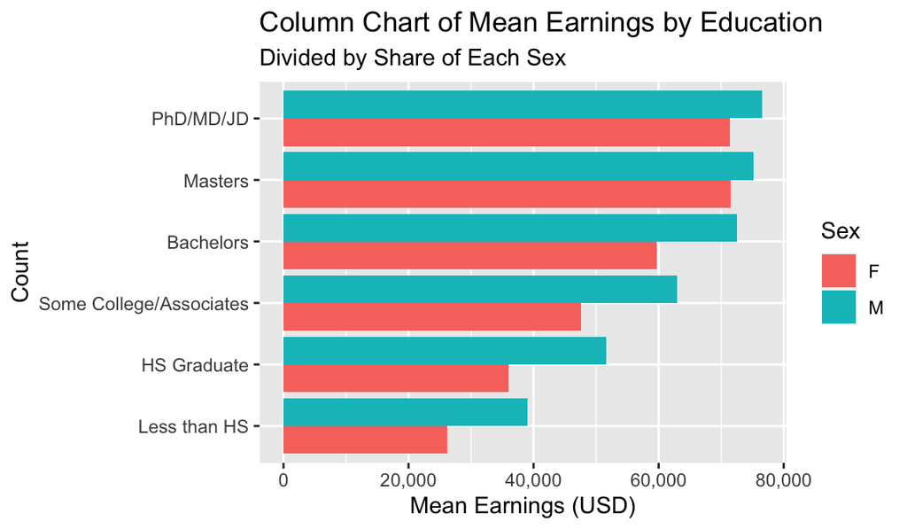

View code-movie in a new tab or below:

[interactive chart not shown]

##### Ex. 4.2: Bar Plot

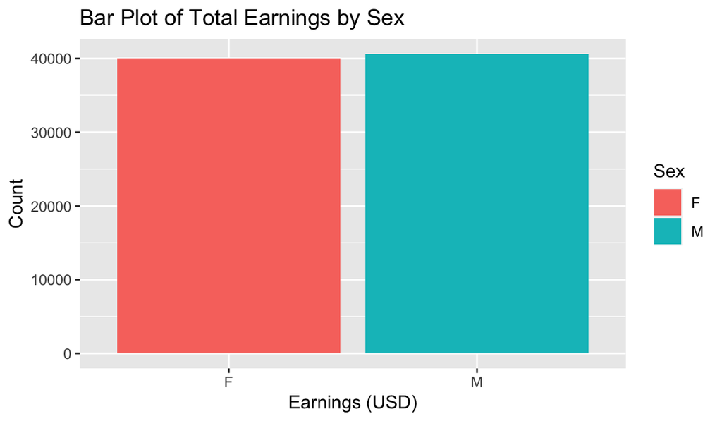

View code-movie in a new tab or below:

[interactive chart not shown]

##### Ex. 4.3: Dot Plot

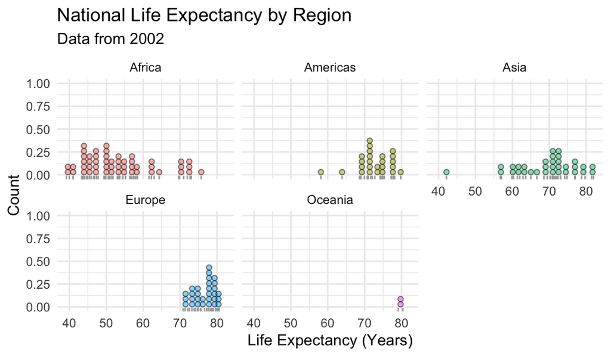

View code-movie in a new tab or below:

[interactive chart not shown]